# Magolego SNA - Lab 6

Danil Gizdatullin, Evgenij Tsymbalov, Andrey Shestakov

05/15/2015

## Motifs

**Motifs** are often defined as recurrent and statistically significant sub-graphs or patterns. Here, we consider motifs as sub-graphs of a given graph, which are isomorphic to defined sample.

Here is our old beloved friend:

```r
library('igraph')
g = graph.famous("Zachary")
```

Let’s define a simple sample motif:

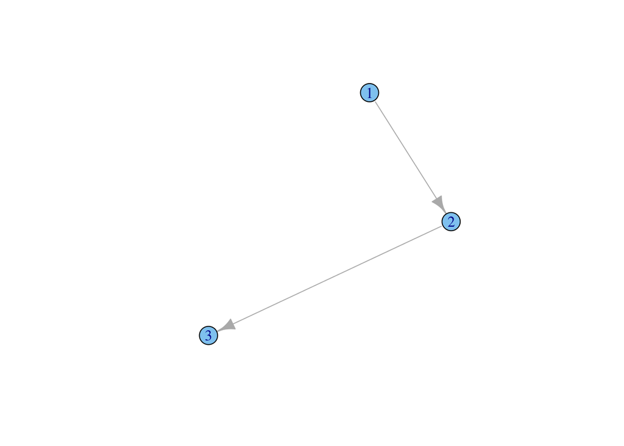

```r
sample = graph(c(c(1,2), c(2,3)))
plot(sample)
```

Now let’s calculate, if it is often in our graph:

```r
isoclass_num = graph.isoclass(sample) # defining number of corresponding isoclass
motifs3 = graph.motifs(g, size = 3)
motifs3[isoclass_num] # returns number of motifs
```

```
## [1] 45
```

Due to high computational time (isomorphism checks), `graph.motifs` are implemented for graps of sizes 3 and 4 only. However, we can easy check numbers for all motifs of size 4 to find more frequent patterns:

```r
motifs4 = graph.motifs(g, size = 4)
```

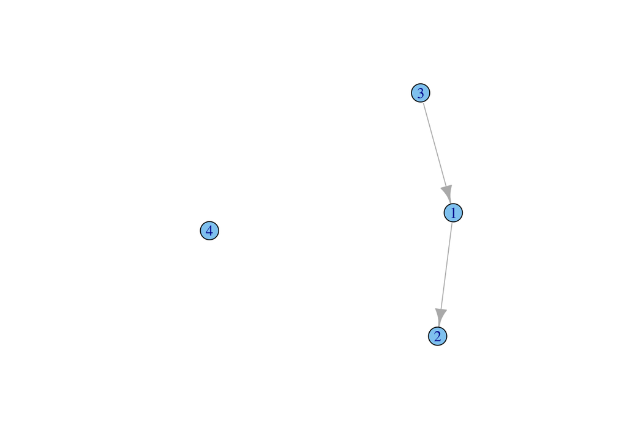

```r
plot(graph.isocreate(size=4, number=5))
```

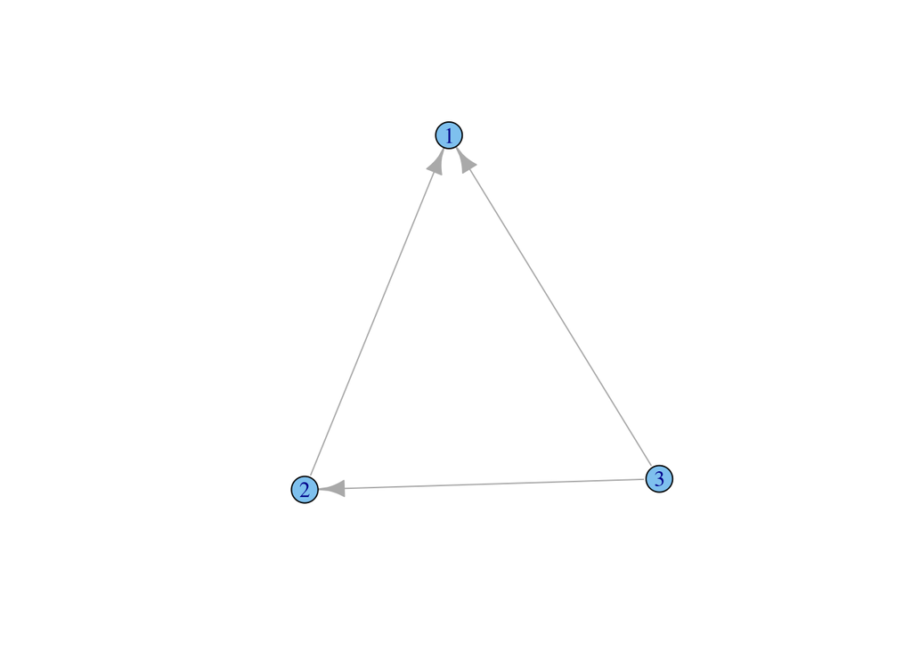

```r
plot(graph.isocreate(size=3, number=7))
```

That is certainly better.

## Visualisation

There are currently three different functions in the igraph package which can draw graph in various ways:

- `plot.igraph` does simple non-interactive 2D plotting to R devices. Actually it is an implementation of the plot generic function, so you can write plot(graph) instead of plot.igraph(graph). As it used the standard R devices it supports every output format for which R has an output device. The list is quite impressing: PostScript, PDF files, XFig files, SVG files, JPG, PNG and of course you can plot to the screen as well using the default devices, or the good-looking anti-aliased Cairo device. See [plot.igraph](http://igraph.org/r/doc/plot.graph.html) for some more information.
- `tkplot` does interactive 2D plotting using the tcltk package. It can only handle graphs of moderate size, a thousend vertices is probably already too many. Some parameters of the plotted graph can be changed interactively after issuing the tkplot command: the position, color and size of the vertices and the color and width of the edges. [See tkplot](http://igraph.org/r/doc/tkplot.html) for details.
- `rglplot` is an experimental function to draw graphs in 3D using OpenGL. See [rglplot](http://igraph.org/r/doc/rglplot.html) for some more information.

Let’s draw a graph-ring using different three methods.

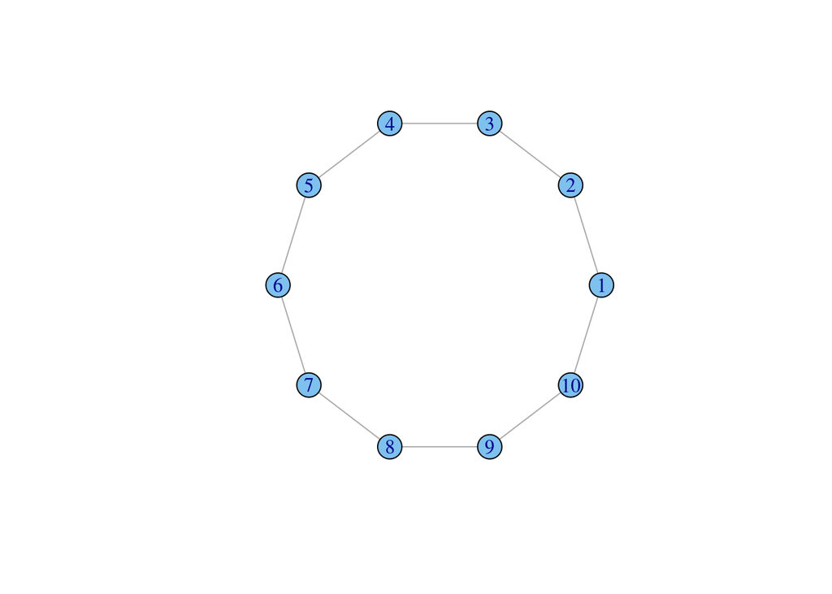

```r
library(igraph)
library(rgl)

g <- graph.ring(10)
g$layout <- layout.circle
plot(g)
```

```r
#doesn't work in R Markdown
tkplot(g)
```

```
## [1] 1
```

```r
rglplot(g)
```

### Layout

Either a function or a numeric matrix. It specifies how the vertices will be placed on the plot.  
Let’s demonstrate how it works on some graph. For example graph which based on barabashi model.

```r
g <- barabasi.game(50)
```

- `layout.auto` - tries to choose an appropriate layout function for the supplied graph, and uses that to generate the layout.

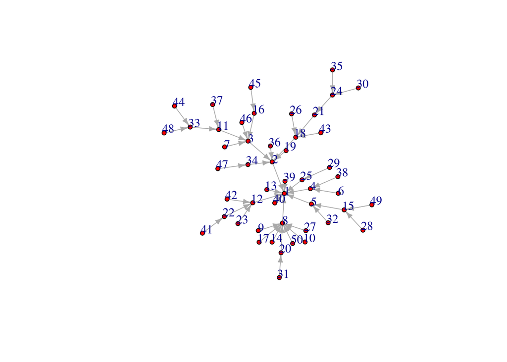

```r
plot(g, layout=layout.auto, vertex.size=4,
     vertex.label.dist=0.5, vertex.color="red", edge.arrow.size=0.5)
```

- `layout.random` - simply places the vertices randomly on a square.

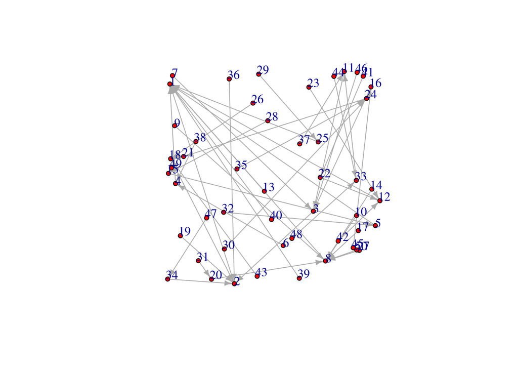

```r
plot(g, layout=layout.random, vertex.size=4,
     vertex.label.dist=0.5, vertex.color="red", edge.arrow.size=0.5)
```

- `layout.circle` - places the vertices on a unit circle equidistantly.

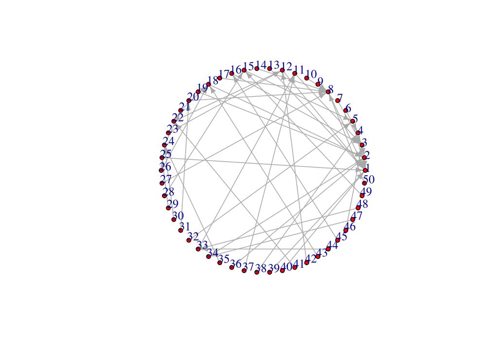

```r
plot(g, layout=layout.circle, vertex.size=4,
     vertex.label.dist=0.5, vertex.color="red", edge.arrow.size=0.5)
```

- `layout.sphere` - places the vertices (approximately) uniformly on the surface of a sphere, this is thus a 3d layout.

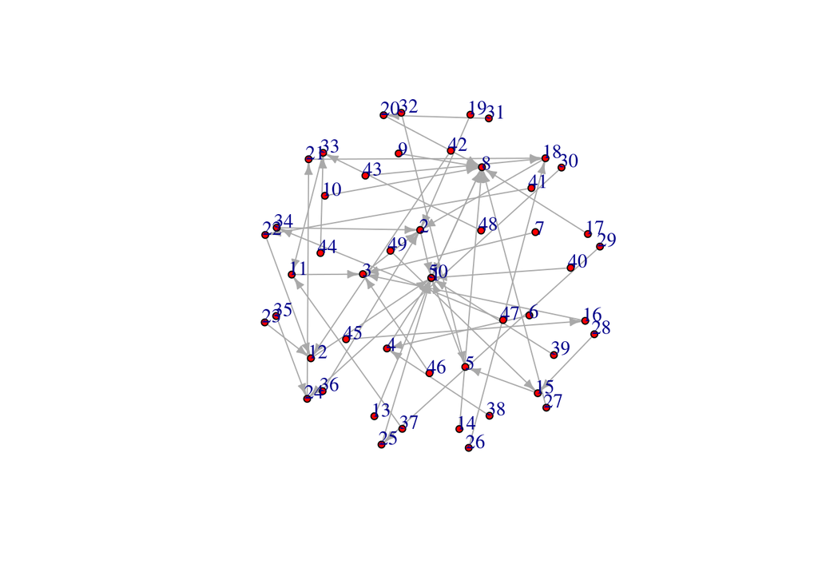

```r
plot(g, layout=layout.sphere, vertex.size=4,
     vertex.label.dist=0.5, vertex.color="red", edge.arrow.size=0.5)
```

- `layout.fruchterman.reingold` uses a force-based algorithm proposed by Fruchterman and Reingold.

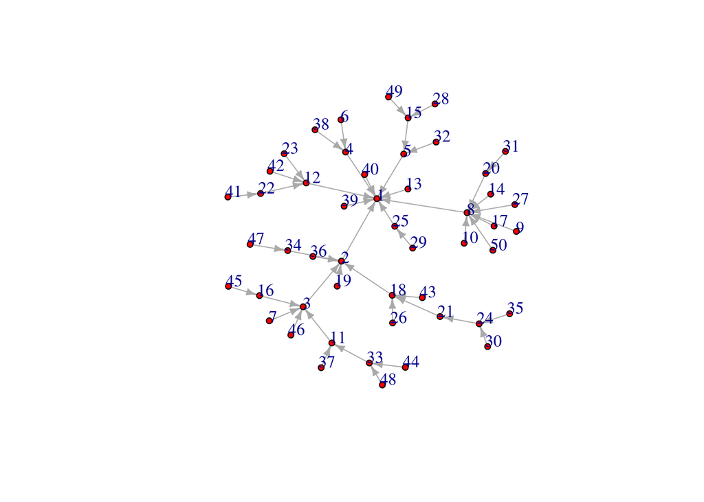

```r
plot(g, layout=layout.fruchterman.reingold, vertex.size=4,
     vertex.label.dist=0.5, vertex.color="red", edge.arrow.size=0.5)
```

- `layout.kamada.kawai` is another force based algorithm.

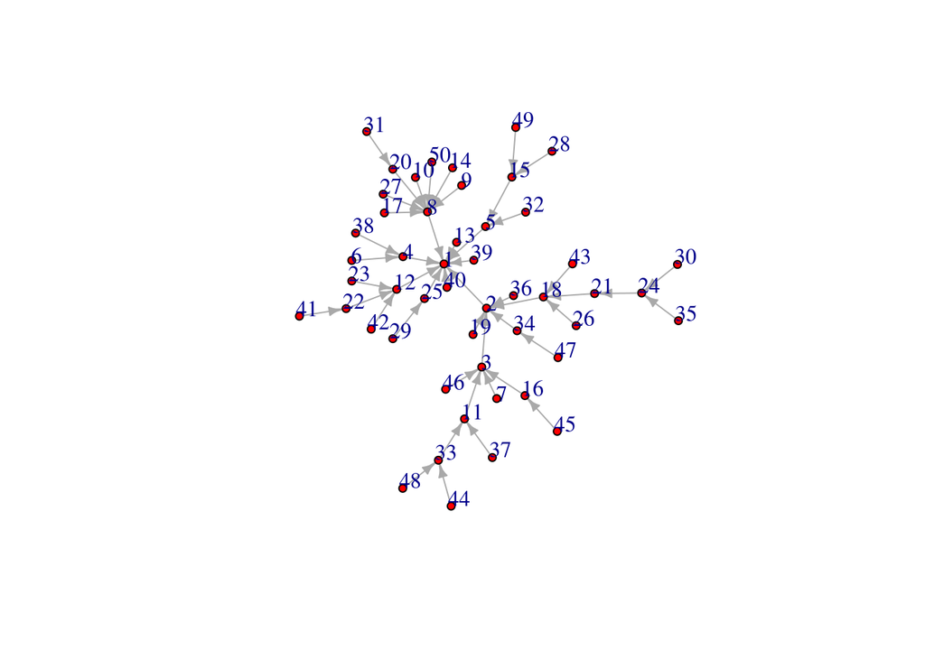

```r
plot(g, layout=layout.kamada.kawai, vertex.size=4,
     vertex.label.dist=0.5, vertex.color="red", edge.arrow.size=0.5)
```

- `layout.spring` is a spring embedder algorithm.

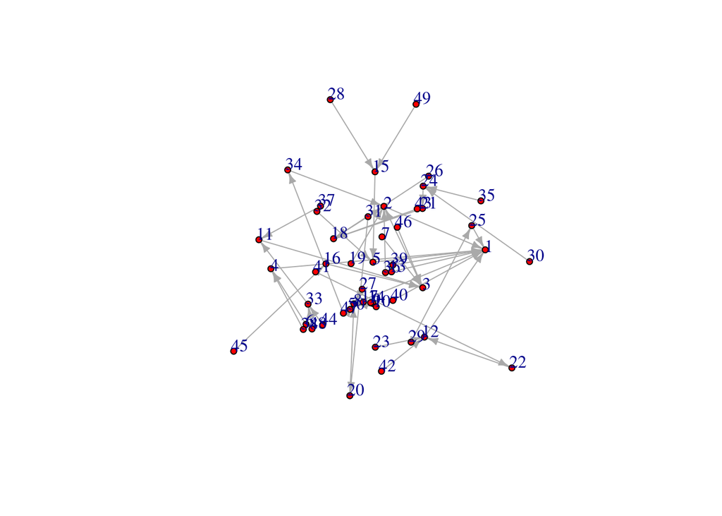

```r
plot(g, layout=layout.spring, vertex.size=4,
     vertex.label.dist=0.5, vertex.color="red", edge.arrow.size=0.5)
```

- `layout.fruchterman.reingold.grid` is similar to layout.fruchterman.reingold but repelling force is calculated only between vertices that are closer to each other than a limit, so it is faster.

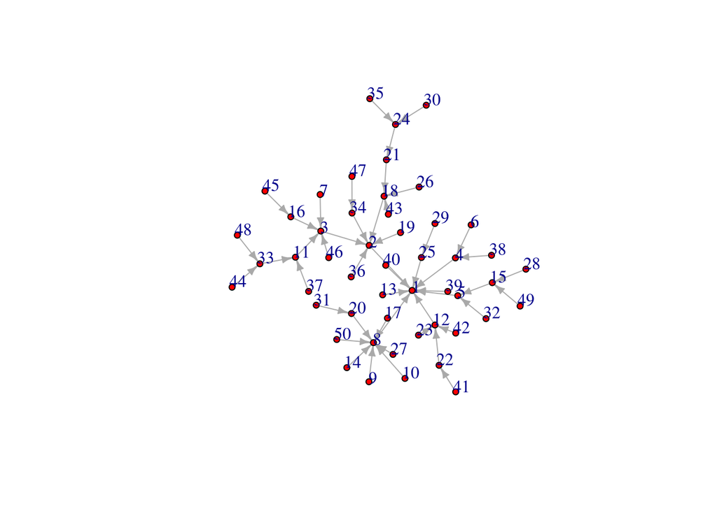

```r
plot(g, layout=layout.fruchterman.reingold.grid, vertex.size=4,
     vertex.label.dist=0.5, vertex.color="red", edge.arrow.size=0.5)
```

- `layout.lgl` is for large connected graphs, it is similar to the layout generator of the Large Graph Layout software http://lgl.sourceforge.net/.

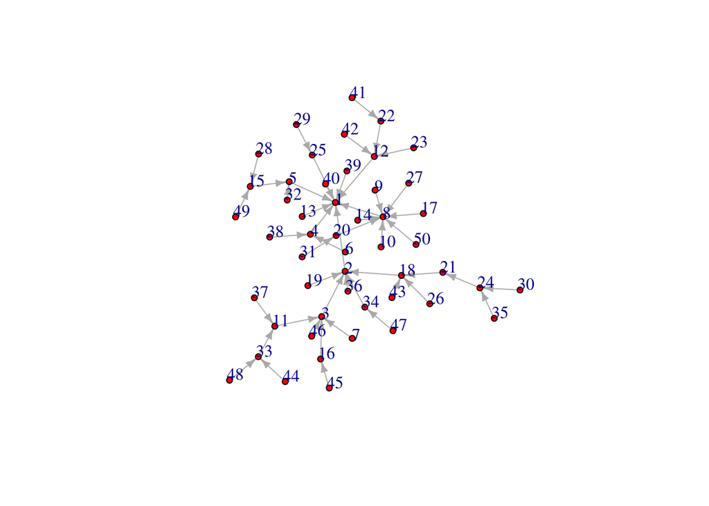

```r
plot(g, layout=layout.lgl, vertex.size=4,
     vertex.label.dist=0.5, vertex.color="red", edge.arrow.size=0.5)
```

- `layout.graphopt` is a port of the graphopt layout algorithm by Michael Schmuhl. graphopt version 0.4.1 was rewritten in C and the support for layers was removed (might be added later) and a code was a bit reorganized to avoid some unneccessary steps is the node charge (see below) is zero.
- `layout.svd` is a currently experimental layout function based on singular value decomposition.
- `layout.norm` normalizes a layout, it linearly transforms each coordinate separately to fit into the given limits.
- `layout.drl` is another force-driven layout generator, it is suitable for quite large graphs.
- `layout.reingold.tilford` generates a tree-like layout, so it is mainly for tree.

### Highlight components

Let’s make different color for each graph component

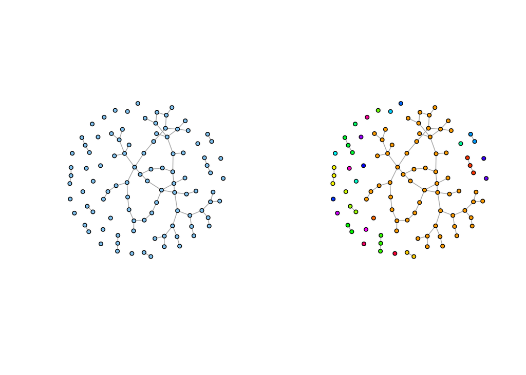

```r
g <- erdos.renyi.game(100, 1/100)

l <- layout.fruchterman.reingold(g)

op = par(mfrow = c(1,2))
plot(g, layout=l, vertex.size=5, vertex.label=NA)

comps <- clusters(g)$membership
colbar <- rainbow(max(comps)+1)
V(g)$color <- colbar[comps+1]

plot(g, layout=l, vertex.size=5, vertex.label=NA)
```

### Highlight communities in graph

Let’s make different color for each community

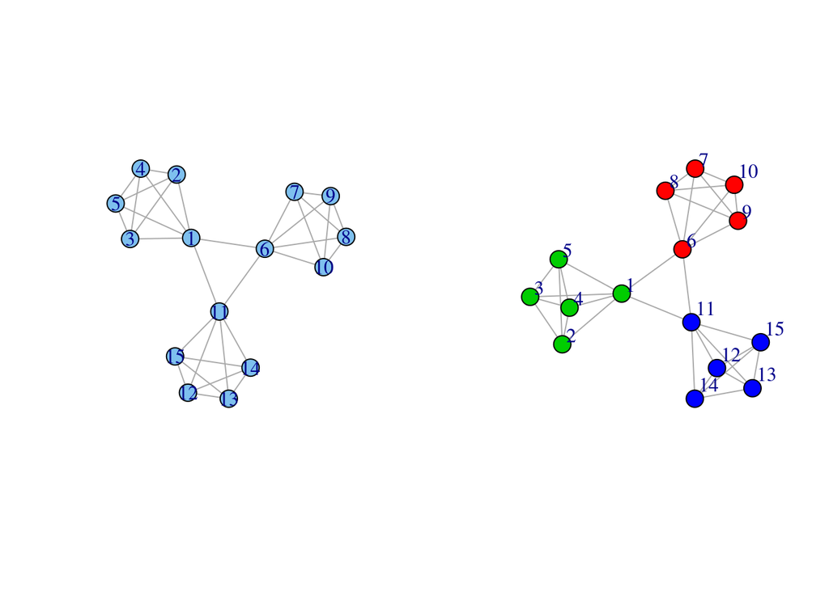

```r
g <- graph.full(5) %du% graph.full(5) %du% graph.full(5)
g <- add.edges(g, c(1,6, 1,11, 6,11))

op = par(mfrow = c(1,2))
plot(g, layout = layout.kamada.kawai)

com <- spinglass.community(g, spins=5)
V(g)$color <- com$membership+1
g <- set.graph.attribute(g, "layout", layout.kamada.kawai(g))
plot(g, vertex.label.dist=1.5)
```

```r
par(op)
```

### Trees Visualization

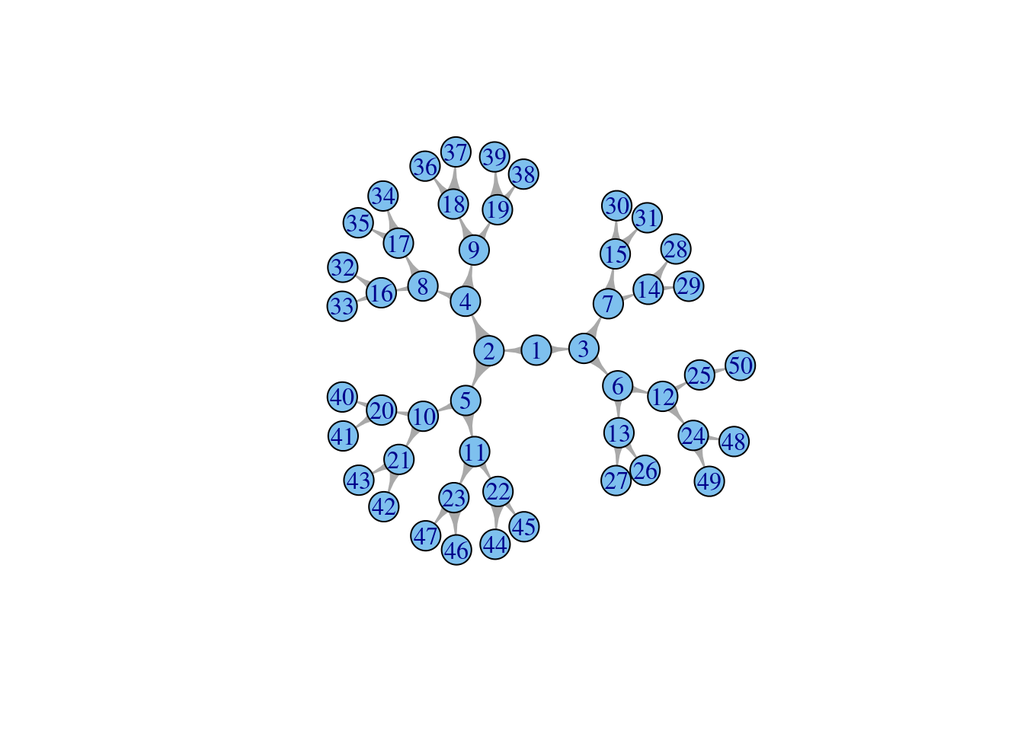

```r
plot(graph.tree(50, 2))
```

We can use `layout = layout.reingold.tilford` to draw tree

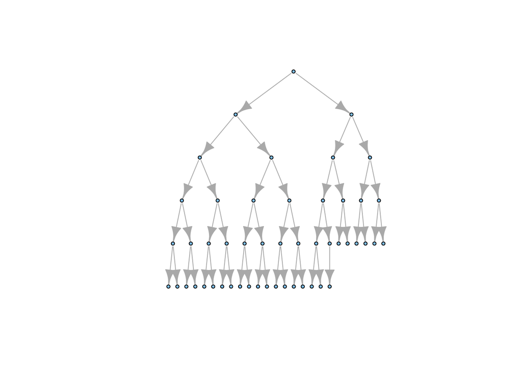

```r
plot(graph.tree(50, 2), vertex.size=3, vertex.label=NA, layout=layout.reingold.tilford)
```

```r
tkplot(graph.tree(50, 2, mode="undirected"), vertex.size=10,
       vertex.color="green")
```

```
## [1] 2
```

## Assortative Mixing

Assortative Mixing coefficient shows whether nodes with the same attribute values tend to form connections. Download [Caltech](https://www.dropbox.com/s/tz9teeaq79n0cx4/Caltech.gml?dl=0) friendship network. Inspect nodes attributes and compute assortativity coefficients with `assortativity` function

```r
# Your code here
g <- read.graph(file = 'Caltech.gml', format = 'gml')
assortativity.nominal(graph = g, types = V(g)$dorm+1, directed = F)
```

```
## [1] 0.3491531
```

## Basic network analysis pipeline

The basic pipeline for exploratory graph analysis consists of:

### Loading

See Seminar 1.

### Cleaning

After loading graph with all necessary attributes, it is often recommended to:

- delete empty nodes:

```r
g = delete.vertices(g, degree(g) == 0)
```

- delete self-cycles and multiple edges - to make graph *simple*. `simplify` does all the work; some parameters could be tuned:

```r
simplify(g)
```

```
## IGRAPH U--- 769 16656 --
## + attr: id (v/n), status (v/n), gender (v/n), magor (v/n),
##   sndmagor (v/n), dorm (v/n), year (v/n), school (v/n)
```

```r
# is.simple(simplify(g, remove.multiple=FALSE))
```

### Obtaining main characteristics

See Seminars 2, 4.

### Clustering

See Seminar 5.

### Visualization

See previous section + Seminars 1, 4.